# Human IRE Analysis

## 1. Defining human IRE gene sets

### 1.1. Introduction

The aim of this analysis is to determine the predicted IREs from the human reference genome, and compare the properties of these to IREs predicted from the zebrafish genome.

### 1.2. Extract UTR sequences from human reference genome

Here we prepare the `hg38` reference genomic ranges with Ensembl IDs rather than the default UCSC IDs:

```r
hg38 <- BSgenome.Hsapiens.UCSC.hg38
ah <- AnnotationHub() %>% subset(species == "Homo sapiens")
gr <- ah[["AH64629"]]

#gr <- gr %>% subset(seqnames %in% c(as.character(1:24), "X", "Y", "MT")) %>% subset(type == "three_prime_utr")

ucscLevels <- seqlevels(hg38)

ensLevels <- ucscLevels %>%
    str_remove_all("^chr") %>%
    str_remove_all("^[0-9Un]+_") %>%
    str_remove_all("_alt") %>%
    str_replace_all("v", ".") %>%
    str_replace_all("^M$", "MT")

ens2Ucsc <- structure(ucscLevels, names = ensLevels)
seqlevels(gr) <- ens2Ucsc[seqlevels(gr)]
seqinfo(gr, new2old = match(seqlevels(hg38), seqlevels(gr))) <- seqinfo(hg38)
```

#### 1.2.1. Extract 3’ UTRs

Subset 3’ UTR sequences:

```r
utr3 <- subset(gr, type == "three_prime_utr")
```

Export 3’ UTRs:

A total of 148,456 sequences were exported

#### 1.2.2. Extract 5’ UTRs

Subset 5’ UTR sequences:

```r
utr5 <- gr%>% subset(type == "five_prime_utr")
```

Export 5’ UTRs

```r
utr5Seq <- Views(hg38, utr5) %>% DNAStringSet()
names(utr5Seq) <- paste(utr5$transcript_id, utr5$gene_name, granges(utr5), sep = "_")
writeXStringSet(utr5Seq, here("R","IREGenes","data","utr5_human.fa.gz"), compress = TRUE)
```

A total of 149,893 sequences were exported.

### 1.3. Import SIREs results

#### 1.3.1. 3’ UTR

Results from scans of the above sequences using the [SIREs website](http://ccbg.imppc.org/sires/) were loaded as data frames, with co-ordinates converted to the underlying genomic co-ordinates, as opposed to being in reference to the submitted sequences.

```r
ireUtr3 <- here("R","IREGenes","data","utr3_human.fa.gff") %>%
    import.gff() %>%
    as.data.frame(stringsAsFactors = FALSE) %>%
    as_tibble()
```

[output not shown]

```r
ireUtr3 %<>%
    mutate(seqnames = as.character(seqnames),
                 seqnames = str_replace(seqnames, "_chrUn_", "_chrUn-")
                 ) %>%
    dplyr::select(-strand) %>%
    separate(seqnames, c("transcript_id", "gene_name", "location"), sep = "_") %>%
    mutate(location = str_replace(location, "chrUn-", "chrUn_")) %>%
    separate(
        location,
        into = c("seqnames", "trans_start", "trans_end", "strand"),
        sep = "[:-]"
    ) %>%
    mutate_at(c("trans_start", "trans_end"), funs(as.integer)) %>%
    mutate(strand = case_when(
        strand == "" ~ "-",
        strand == "+" ~ "+"
    ),
    start = ifelse(
        strand == "+",
        trans_start + start - 1L,
        trans_end - end + 1L
    ),
    end = start + width - 1) %>%
    dplyr::select(-contains("trans_")) %>%
    makeGRangesFromDataFrame(
        keep.extra.columns = TRUE,
        seqinfo = seqinfo(gr),
        seqnames.field = "seqnames",
        start.field = "start",
        end.field = "end",
        strand.field = "strand")
```

```
Expected 4 pieces. Additional pieces discarded in 3613 rows [1, 2, 5, 6, 7, 8, 10, 11, 12, 13, 14, 15, 16, 17, 18, 19, 20, 34, 38, 39, ...].
```

```r
ireUtr3$gene_id <- mcols(gr)$gene_id[match(ireUtr3$transcript_id, gr$transcript_id)]
```

A total of 7,213 IREs were found across 3,041 genes when inspecting the 3’UTR sequences. These can be summarised as:

```
  * **c8_class**:

    --------------
     good   wrong
    ------ -------
     2695   4518
    --------------

  * **pred_loop_class**:

    --------------
     good   wrong
    ------ -------
     2247   4966
    --------------

  * **pairs_class**:

    -------------
     good    ok
    ------ ------
     1707   5506
    -------------

  * **quality**:

    ----------------------
     High   Low    Medium
    ------ ------ --------
     616    4300    2297
    ----------------------


<!-- end of list -->
```

#### 1.3.2. 5’ UTR

The same process was repeated for 5’ UTR IREs, with the exception that this time the gene *TMCC1* required manual correcting.

```r
ireUtr5 <- here::here("R","IREGenes","data","utr5_human.fa.gff") %>%
    import.gff() %>%
    as.data.frame(stringsAsFactors = FALSE) %>%
    as_tibble()
```

The loaded matches to IREs in the UTR5 were then converted to a GRanges object.

```r
ireUtr5 %<>%
    mutate(seqnames = as.character(seqnames),
                 seqnames = str_replace(seqnames, "_chrUn_", "_chrUn-")) %>%
    dplyr::select(-strand) %>%
    separate(seqnames, c("transcript_id", "gene_name", "location"), sep = "_") %>%
    mutate(location = str_replace(location, "chrUn-", "chrUn_")) %>%
    separate(
        location,
        into = c("seqnames", "trans_start", "trans_end", "strand"),
        sep = "[:-]"
    ) %>%
    mutate_at(c("trans_start", "trans_end"), funs(as.integer)) %>%
    mutate(strand = case_when(
        strand == "" ~ "-",
        strand == "+" ~ "+"
    ),
    start = ifelse(
        strand == "+",
        trans_start + start - 1L,
        trans_end - end + 1L
    ),
    end = start + width - 1) %>%
    dplyr::select(-contains("trans_")) %>%
    makeGRangesFromDataFrame(
        keep.extra.columns = TRUE,
        seqinfo = seqinfo(gr),
        seqnames.field = "seqnames",
        start.field = "start",
        end.field = "end",
        strand.field = "strand")
```

```
Expected 4 pieces. Additional pieces discarded in 1320 rows [4, 9, 10, 11, 12, 13, 14, 20, 21, 22, 23, 24, 25, 26, 29, 30, 33, 34, 36, 38, ...].
```

```r
ireUtr5$gene_id <- mcols(gr)$gene_id[match(ireUtr5$transcript_id, gr$transcript_id)]
```

A total of 2,642 IREs were found across 1,265 genes when inspecting the 5’UTR sequences. These can be summarised as:

```
  * **c8_class**:

    --------------
     good   wrong
    ------ -------
     851    1791
    --------------

  * **pred_loop_class**:

    --------------
     good   wrong
    ------ -------
     780    1862
    --------------

  * **pairs_class**:

    -------------
     good    ok
    ------ ------
     610    2032
    -------------

  * **quality**:

    ----------------------
     High   Low    Medium
    ------ ------ --------
     224    1576    842
    ----------------------


<!-- end of list -->
```

## 1.4. Enrichment Analysis

### 1.4.1. Gene Set Definitions

At this point, we need to create multiple (overlapping) gene sets which define the putative IREs. The initial gene-sets being formed are:

- **3’UTR HQ**: The High quality IREs in the 3’ UTR
- **3’UTR ALL**: All putative IREs in the 3’UTR
- **5’UTR HQ**: The High quality IREs in the 5’ UTR
- **5’UTR ALL**: All putative IREs in the 5’UTR

```r
ireSets <- list(
    utr3HQ = ireUtr3 %>%
        subset(quality == "High") %>%
        mcols() %>%
        extract2("gene_name") %>%
        unique(),
    utr3ALL = ireUtr3 %>%
        mcols() %>%
        extract2("gene_name") %>%
        unique(),
    utr5HQ = ireUtr5 %>%
        subset(quality == "High") %>%
        mcols() %>%
        extract2("gene_name") %>%
        unique(),
    utr5ALL = ireUtr5 %>%
        mcols() %>%
        extract2("gene_name") %>%
        unique()
)
```

This gave gene sets of the following sizes:

```
-------------------------------------
 utr3HQ   utr3ALL   utr5HQ   utr5ALL
-------- --------- -------- ---------
  325      3041      106      1265
-------------------------------------
```

## 2. Import human sAD dataset

- In this analysis, we will be using the Mayo dataset.

### 2.1. Data Description

- **Tissue**: Human cerebellum and temporal cortex
- **Platform**: Illumina HiSeq 2000, 101 bp, paired end RNA-seq
- **URL**: [Synapse](https://www.synapse.org/#!Synapse:syn5550404)
- **Samples**: Post mortem AD cases (Braak >= 4.0), pathological diagnosis of PSP (Braak <= 3), pathologic aging (Braak <= 3), elderly control (Braak <= 3)
- **Study Description**: This study is independent of studies described under the Mayo Clinic Alzheimer’s Disease Genetics Studies (MCADGS). Data is provided for the Mayo RNAseq Study, with whole transcriptome data for 275 Cerebellum (CBE) and 276 Temporal cortex (TCX) samples from 312 North American Caucasian subjects with neuropathological diagnosis of AD, progressive supranuclear palsy (PSP), pathologic aging (PA) or elderly controls (CON) without neurodegenerative diseases. Within this cohort, all AD and PSP subjects were from the Mayo Clinic Brain Bank (MCBB), and all PA subjects were obtained from the Banner Sun Health Research Institute (Banner). Thirty-four control CBE and 31 control TCX samples were from the MCBB, and the remaining control tissue was from Banner. All subjects selected from the MCBB and Banner underwent neuropathologic evaluation by Dr. Dennis Dickson or Dr. Thomas Beach, respectively. All ADs had definite diagnosis according to the NINCDS-ADRDA criteria and had Braak NFT stage of IV or greater. Control subjects had Braak NFT stage of III or less, CERAD neuritic and cortical plaque densities of 0 (none) or 1 (sparse) and lacked any of the following pathologic diagnoses: AD, Parkinson’s disease (PD), DLB, VaD, PSP, motor neuron disease (MND), CBD, Pick’s disease (PiD), Huntington’s disease (HD), FTLD, hippocampal sclerosis (HipScl) or dementia lacking distinctive histology (DLDH). Subjects with PA also lacked the above diagnoses and had Braak NFT stage of III or less, but had CERAD neuritic and cortical plaque densities of 2 or more. None of the PA subjects had a clinical diagnosis of dementia or mild cognitive impairment.

### 2.2. Data Import and Pre-processing

- First we wmport the gene counts and sample tables for the cerebellum (CBE) and temporal cortex (TCX) samples:

```r
data_mayo$samples_cbe %<>%
  filter(SampleID %in% colnames(data_mayo$counts_cbe), !is.na(Diagnosis)) %>%
  mutate(Name = gsub(x = SampleID, pattern = "_CER", replacement = ""))
data_mayo$samples_tcx %<>%
  filter(ID %in% colnames(data_mayo$counts_tcx), !is.na(Diagnosis)) %>%
  dplyr::rename(SampleID = ID) %>%
  mutate(Name = gsub(x = SampleID, pattern = "_TCX", replacement = ""))
# Reorder the samples n the count matrices to be in the same order as the sample tables.
data_mayo$counts_cbe %<>% magrittr::extract(, c("ensembl_id", data_mayo$samples_cbe$SampleID))
data_mayo$counts_tcx %<>% magrittr::extract(, c("ensembl_id", data_mayo$samples_tcx$SampleID))
# Remove genes that don't have counts measured in all samples in either the CBE or TCX datasets
data_mayo$counts_cbe %<>%
  filter(complete.cases(.)) %>%
  as.data.frame %>%
  column_to_rownames("ensembl_id")
data_mayo$counts_tcx %<>%
  filter(complete.cases(.)) %>%
  as.data.frame %>%
  column_to_rownames("ensembl_id")
lapply(data_mayo, dim)
```

```
$counts_cbe
[1] 64253   271

$counts_tcx
[1] 64253   274

$samples_cbe
[1] 271  11

$samples_tcx
[1] 274  11
```

- Sample information:

```r
data_mayo$samples_cbe
```

| SampleID | Source | Tissue | RIN | Diagnosis | Sex | AgeAtDeath | ApoE | Flowcell | PMI | Name |
| --- | --- | --- | --- | --- | --- | --- | --- | --- | --- | --- |
| 11492_CER | MayoBrainBank_Dickson | Cerebellum | 9.2 | PSP | M | 73 | 33 | FCC7BR1ACXX | 1.00 | 11492 |
| 6810_CER | MayoBrainBank_Dickson | Cerebellum | 8.9 | PSP | M | 74 | 33 | FCC7AFDACXX | 1.00 | 6810 |
| 1046_CER | MayoBrainBank_Dickson | Cerebellum | 9.2 | AD | F | 72 | 33 | FCC7E15ACXX | 2.00 | 1046 |
| 1924_CER | MayoBrainBank_Dickson | Cerebellum | 5.5 | Control | F | 90_or_above | 33 | FCC7983ACXX | 2.00 | 1924 |
| 1926_CER | MayoBrainBank_Dickson | Cerebellum | 7.7 | Control | F | 88 | 33 | FCC7E15ACXX | 2.00 | 1926 |
| 1958_CER | MayoBrainBank_Dickson | Cerebellum | 7.0 | Control | F | 90_or_above | 33 | FCC7KRCACXX | 2.00 | 1958 |
| 6913_CER | MayoBrainBank_Dickson | Cerebellum | 8.9 | PSP | F | 79 | 33 | FCC7LB6ACXX | 2.00 | 6913 |
| 892_CER | MayoBrainBank_Dickson | Cerebellum | 8.9 | AD | M | 84 | 33 | FCC7KRCACXX | 2.00 | 892 |
| 11255_CER | MayoBrainBank_Dickson | Cerebellum | 8.8 | PSP | F | 69 | 33 | FCC7L2YACXX | 3.00 | 11255 |
| 11267_CER | MayoBrainBank_Dickson | Cerebellum | 7.9 | PSP | F | 70 | 33 | FCC7KRCACXX | 3.00 | 11267 |

[output cut: 261 more lines]

```r
data_mayo$samples_tcx
```

| SampleID | Source | Tissue | RIN | Diagnosis | Gender | AgeAtDeath | ApoE | FLOWCELL | PMI | Name |
| --- | --- | --- | --- | --- | --- | --- | --- | --- | --- | --- |
| 11492_TCX | MayoBrainBank_Dickson | TemporalCortex | 10.0 | PSP | M | 73 | 33 | BC47ADACXX | 1.00 | 11492 |
| 6810_TCX | MayoBrainBank_Dickson | TemporalCortex | 8.0 | PSP | M | 74 | 33 | AC5R6PACXX | 1.00 | 6810 |
| 1046_TCX | MayoBrainBank_Dickson | TemporalCortex | 9.0 | AD | F | 72 | 33 | BC5RNRACXX | 2.00 | 1046 |
| 1924_TCX | MayoBrainBank_Dickson | TemporalCortex | 5.6 | Control | F | 90_or_above | 33 | AC5R6PACXX | 2.00 | 1924 |
| 1926_TCX | MayoBrainBank_Dickson | TemporalCortex | 7.8 | Control | F | 88 | 33 | AC44HKACXX | 2.00 | 1926 |
| 6913_TCX | MayoBrainBank_Dickson | TemporalCortex | 8.3 | PSP | F | 79 | 33 | AC44HKACXX | 2.00 | 6913 |
| 892_TCX | MayoBrainBank_Dickson | TemporalCortex | 8.4 | AD | M | 84 | 33 | AC5RKCACXX | 2.00 | 892 |
| 11255_TCX | MayoBrainBank_Dickson | TemporalCortex | 8.5 | PSP | F | 69 | 33 | BC6178ACXX | 3.00 | 11255 |
| 11267_TCX | MayoBrainBank_Dickson | TemporalCortex | 7.8 | PSP | F | 70 | 33 | BC5RNRACXX | 3.00 | 11267 |
| 11306_TCX | MayoBrainBank_Dickson | TemporalCortex | 7.9 | PSP | F | 73 | 33 | AC44HKACXX | 3.00 | 11306 |

[output cut: 264 more lines]

- Merge the TCX and CBE datasets, retaining samples and genes that are present in both datasets:

```r
data_mayo$samples_tcx %<>% dplyr::rename(Sex=Gender, Flowcell=FLOWCELL)
keepSamples <- inner_join(data_mayo$samples_cbe,
                            data_mayo$samples_tcx,
                            by = c("Name", "Diagnosis", "Sex", "ApoE", "PMI", "AgeAtDeath"),
                            suffix = c("_CBE", "_TCX"))
mergedSamples <- rbind(data_mayo$samples_cbe, data_mayo$samples_tcx) %>%
  filter(Name %in% keepSamples$Name)
mergedCounts <- inner_join(data_mayo$counts_cbe %>% rownames_to_column("ensembl_id"),
                           data_mayo$counts_tcx%>% rownames_to_column("ensembl_id"),
                           by = "ensembl_id") %>%
  magrittr::extract(, c("ensembl_id", mergedSamples$SampleID)) %>%
  column_to_rownames("ensembl_id")
mergedSamples # Preview the samples table
```

| SampleID | Source | Tissue | RIN | Diagnosis | Sex | AgeAtDeath | ApoE | Flowcell | PMI | Name |
| --- | --- | --- | --- | --- | --- | --- | --- | --- | --- | --- |
| 11492_CER | MayoBrainBank_Dickson | Cerebellum | 9.2 | PSP | M | 73 | 33 | FCC7BR1ACXX | 1.00 | 11492 |
| 6810_CER | MayoBrainBank_Dickson | Cerebellum | 8.9 | PSP | M | 74 | 33 | FCC7AFDACXX | 1.00 | 6810 |
| 1046_CER | MayoBrainBank_Dickson | Cerebellum | 9.2 | AD | F | 72 | 33 | FCC7E15ACXX | 2.00 | 1046 |
| 1924_CER | MayoBrainBank_Dickson | Cerebellum | 5.5 | Control | F | 90_or_above | 33 | FCC7983ACXX | 2.00 | 1924 |
| 1926_CER | MayoBrainBank_Dickson | Cerebellum | 7.7 | Control | F | 88 | 33 | FCC7E15ACXX | 2.00 | 1926 |
| 6913_CER | MayoBrainBank_Dickson | Cerebellum | 8.9 | PSP | F | 79 | 33 | FCC7LB6ACXX | 2.00 | 6913 |
| 892_CER | MayoBrainBank_Dickson | Cerebellum | 8.9 | AD | M | 84 | 33 | FCC7KRCACXX | 2.00 | 892 |
| 11255_CER | MayoBrainBank_Dickson | Cerebellum | 8.8 | PSP | F | 69 | 33 | FCC7L2YACXX | 3.00 | 11255 |
| 11267_CER | MayoBrainBank_Dickson | Cerebellum | 7.9 | PSP | F | 70 | 33 | FCC7KRCACXX | 3.00 | 11267 |
| 11306_CER | MayoBrainBank_Dickson | Cerebellum | 6.7 | PSP | F | 73 | 33 | FCC7E15ACXX | 3.00 | 11306 |

[output cut: 462 more lines]

```r
mergedCounts # Preview the gene counts
```

[output not shown]

[output cut: 78 more lines]

```
ENSG00000000003       231       342       583       400       402       471       742       544       401       411
ENSG00000000005         4         4         4         5         2         4         1         4         6         3
                11443_TCX 11447_TCX 11448_TCX 11449_TCX 11456_TCX 11457_TCX 11460_TCX 11465_TCX 11491_TCX 11494_TCX
ENSG00000000003       679       469       429       878       356       413       461       473       439       624
ENSG00000000005         2         3         2         6         4         8         0         2         4         7
                11495_TCX 11497_TCX 11499_TCX 11500_TCX 11502_TCX 11503_TCX 11505_TCX 11506_TCX 1200_TCX 1214_TCX
ENSG00000000003       468      1010       635       472       737       484       401       712     1052      637
ENSG00000000005         2         4         8         2         1         0         5         6        5        4
                1271_TCX 134_TCX 135_TCX 1932_TCX 1937_TCX 1945_TCX 6819_TCX 6821_TCX 6870_TCX 6872_TCX 6914_TCX 6929_TCX
ENSG00000000003      809     931    1200      259      340      444      378      587      481      370      483      395
ENSG00000000005        6       1       5        2        5        4        3        7        3        3        2        8
                731_TCX 744_TCX 751_TCX 775_TCX 783_TCX 797_TCX 834_TCX 851_TCX 871_TCX 991_TCX
ENSG00000000003     319     423     468     372     249     766    1637     601     232     945
ENSG00000000005       2       4       5       9       0       2       0       6       3       9
 [ reached 'max' / getOption("max.print") -- omitted 64251 rows ]
```

### 2.3. Sample info

- Number of individuals in this dataset for which we have both cerebellum and temporal cortex measurements:

| Tissue | n |
| --- | --- |
| Cerebellum | 236 |
| TemporalCortex | 236 |

Number of female (F) and male (M) individuals in the dataset:

| Sex | n |
| --- | --- |
| F | 226 |
| M | 246 |

Age distribution of individuals is biased towards older individuals > 75 years old.

```r
mergedSamples2 <- mergedSamples %>% mutate(AgeAtDeath = as.numeric(gsub(x = AgeAtDeath, pattern = "90_or_above", replacement = 91)))
paste0("Mean age: ", round(mean(mergedSamples2$AgeAtDeath),1))
```

```
[1] "Mean age: 79.8"
```

```r
paste0("Median age: ", round(median(mergedSamples2$AgeAtDeath),1))
```

```
[1] "Median age: 81"
```

```r
paste0("Standard deviation of age: ", round(sd(mergedSamples2$AgeAtDeath),1))
```

```
[1] "Standard deviation of age: 8.4"
```

```r
paste0("Median absolute deviation of age: ", round(mad(mergedSamples2$AgeAtDeath),1))
```

```
[1] "Median absolute deviation of age: 8.9"
```

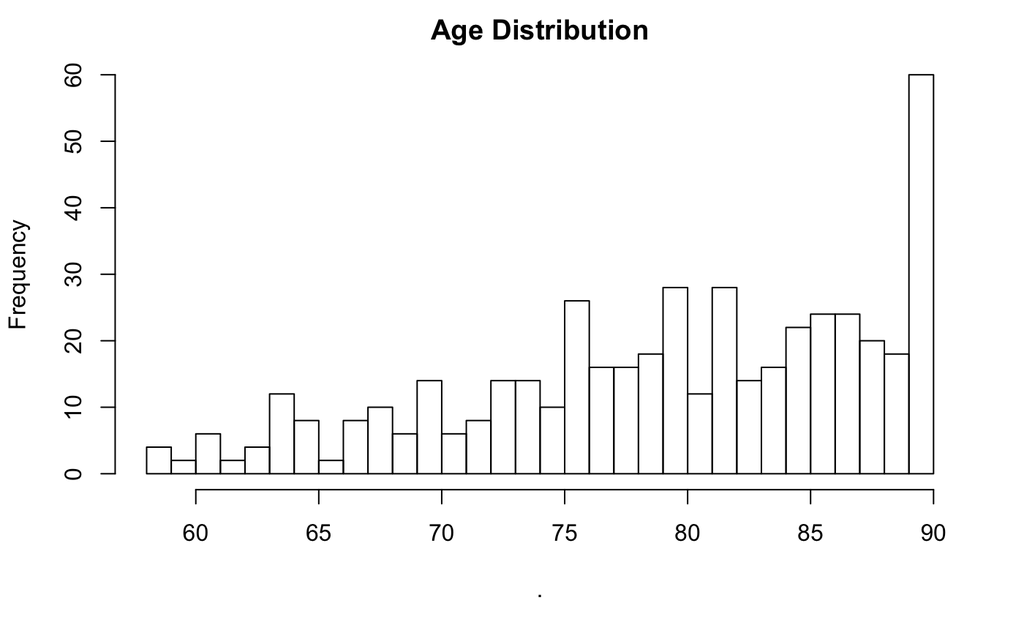

```r
mergedSamples %>%
  mutate(AgeAtDeath = as.numeric(gsub(x = AgeAtDeath, pattern = "90_or_above", replacement = 90)) ) %>%
  use_series("AgeAtDeath") %>%
  hist(main="Age Distribution", breaks=30)
```

Are age distributions equally represented in each gender?

```r
mergedSamples2 %>% dplyr::group_by(AgeAtDeath, Sex) %>% dplyr::summarise(n=dplyr::n())
```

| AgeAtDeath | Sex | n |
| --- | --- | --- |
| 58 | F | 2 |
| 59 | F | 2 |
| 60 | F | 2 |
| 61 | M | 6 |
| 62 | M | 2 |
| 63 | M | 4 |
| 64 | F | 4 |
| 64 | M | 8 |
| 65 | F | 4 |
| 65 | M | 4 |

[output cut: 47 more lines]

```r
mergedSamples2 %>%
  dplyr::group_by(Sex) %>%
  dplyr::summarise(mean=mean(AgeAtDeath),
                   median=median(AgeAtDeath),
                   sd = sd(AgeAtDeath),
                   mad = mad(AgeAtDeath))
```

| Sex | mean | median | sd | mad |
| --- | --- | --- | --- | --- |
| F | 80.62832 | 82 | 8.412895 | 8.8956 |
| M | 79.06504 | 80 | 8.267704 | 8.8956 |

Number of individuals with each diagnosis. The pathologic aging group has significantly fewer individuals (n=44). The number of males and females in each group is not equal, but not too different that it should bias the results.

| Diagnosis | Sex | n |
| --- | --- | --- |
| AD | F | 76 |
| AD | M | 58 |
| Control | F | 60 |
| Control | M | 70 |
| Pathologic Aging | F | 24 |
| Pathologic Aging | M | 20 |
| PSP | F | 66 |
| PSP | M | 98 |

Most individuals have the 3/3 ApoE genotype or the 3/4 ApoE genotype. However, some individuals have other ones too.

```r
mergedSamples2 %>% dplyr::group_by(ApoE) %>% dplyr::summarise(n=dplyr::n())
```

| ApoE | n |
| --- | --- |
| 22 | 2 |
| 23 | 54 |
| 24 | 4 |
| 33 | 288 |
| 34 | 112 |
| 44 | 12 |

### 2.4. Principal Component Analysis

Principal component analysis of the combined TCX and CBE samples:

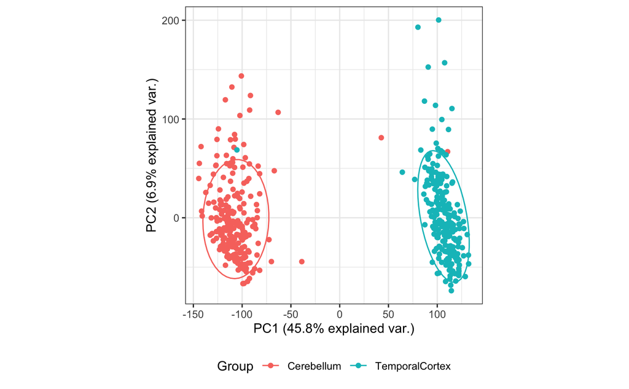

```r
pcaCounts <- mergedCounts %>% cpm(log=T) %>% t %>% prcomp
ggbiplot::ggbiplot(pcaCounts,
                   choices = c(1,2),
                     obs.scale = 1,
                     var.scale = 1,
                     labels.size = 1,
                     var.axes = FALSE,
                     varname.size = 1,
                     groups = mergedSamples$Tissue,
                     ellipse = TRUE,
                     circle = TRUE) +
    scale_color_discrete(name = "Group") +
    theme(legend.direction = "horizontal",
          legend.position = "bottom",
          aspect.ratio = 1)
```

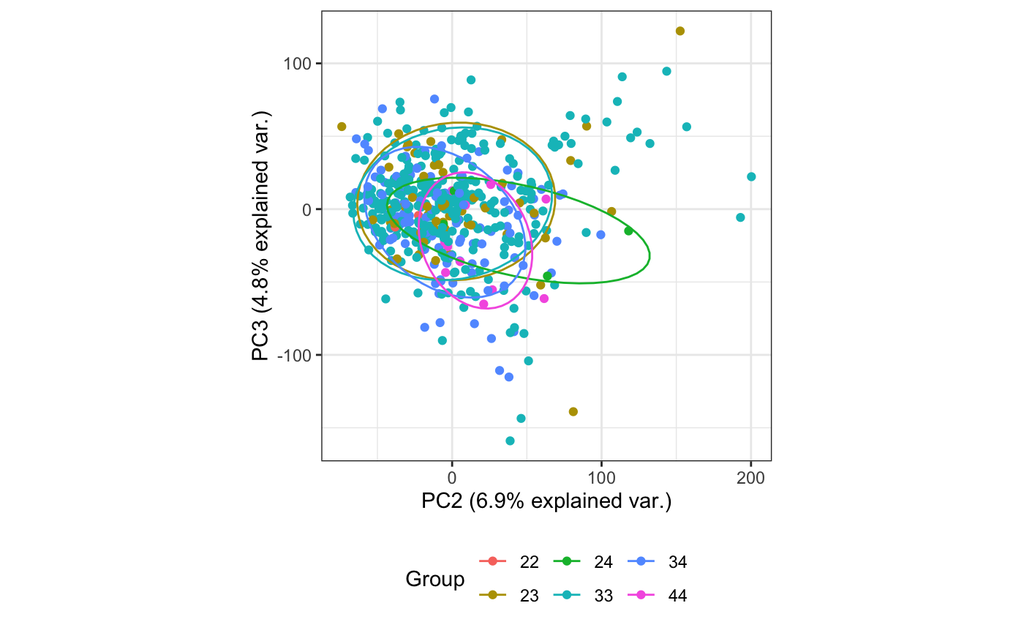

```r
ggbiplot::ggbiplot(pcaCounts,
                   choices = c(2,3),
                     obs.scale = 1,
                     var.scale = 1,
                     labels.size = 1,
                     var.axes = FALSE,
                     varname.size = 1,
                     groups = as.factor(mergedSamples$ApoE),
                     ellipse = TRUE,
                     circle = TRUE) +
    scale_color_discrete(name = "Group") +
    theme(legend.direction = "horizontal",
          legend.position = "bottom",
          aspect.ratio = 1)
```

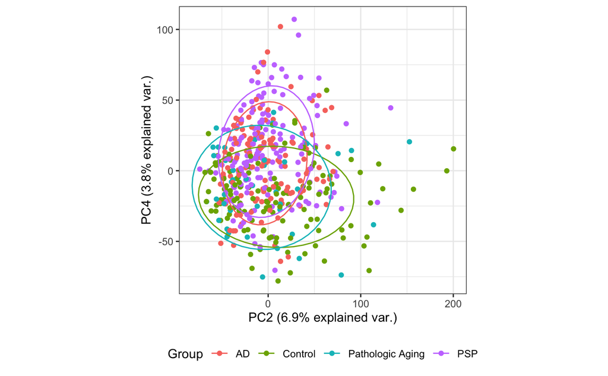

```r
ggbiplot::ggbiplot(pcaCounts,
                   choices = c(2,4),
                     obs.scale = 1,
                     var.scale = 1,
                     labels.size = 1,
                     var.axes = FALSE,
                     varname.size = 1,
                     groups = as.factor(mergedSamples$Diagnosis),
                     ellipse = TRUE,
                     circle = TRUE) +
    scale_color_discrete(name = "Group") +
    theme(legend.direction = "horizontal",
          legend.position = "bottom",
          aspect.ratio = 1)
```

### 2.5. BioMart Gene Annotation

Retrieve gene information from BioMart.

```r
# Load human biomart object
huMart <- useMart("ENSEMBL_MART_ENSEMBL", dataset = "hsapiens_gene_ensembl")

# Retrieve gene annotations from BioMart.
genes <- getBM(
  attributes = c("ensembl_gene_id", "external_gene_name", "description", "gene_biotype"),
  filters = "ensembl_gene_id",
  values = rownames(mergedCounts),
  mart = huMart)

genes2 <- as.data.frame(org.Hs.egENSEMBL) %>%
  left_join(as.data.frame(org.Hs.egSYMBOL)) %>%
  left_join(as.data.frame(org.Hs.egGENENAME))

genes3 <- mergedCounts %>% rownames_to_column("ensembl_gene_id") %>%
  left_join(genes, by = c("ensembl_gene_id")) %>%
  distinct(ensembl_gene_id, .keep_all = TRUE) %>%
  dplyr::select(-contains("TCX"), -contains("CER"))%>%
  column_to_rownames("ensembl_gene_id")

# genes2 <- genes %>%
#   right_join(mergedCounts %>% rownames_to_column("ensembl_gene_id")) %>%
#   dplyr::select(-contains("TCX"), -contains("CER")) %>%
#   column_to_rownames("ensembl_gene_id") %>%
#   extract(rownames(mergedCounts),) %>%
#   rownames_to_column("ensembl_gene_id") %>%
#   filter(complete.cases(.)) %>%
#   column_to_rownames("ensembl_gene_id")
#
# genes2 <- genes %>%
#   mutate(
#     gene_gc_content = percentage_gene_gc_content/100,
#     length = end_position-start_position
#     ) %>%
#   dplyr::select(-percentage_gene_gc_content, -end_position, -start_position) %>%
#   column_to_rownames("ensembl_gene_id") %>%
#   extract(rownames(mergedCounts),) %>%
#   rownames_to_column("ensembl_gene_id") %>%
#   filter(complete.cases(.)) %>%
#   column_to_rownames("ensembl_gene_id")
#
# mergedCounts %<>% extract(rownames(genes2),)

genes3
dim(genes3)
dim(mergedCounts)
table(rownames(genes3)==rownames(mergedCounts))
```

[output not shown]

### 2.6. DGEList and Normalisation

```r
mayo_DGE <- DGEList(
  counts = mergedCounts,
  samples = mergedSamples,
  genes = genes3,
  remove.zeros = TRUE
) %>%
  calcNormFactors("TMM")
```

```
Removing 15269 rows with all zero counts
```

```r
mayo_DGE$samples %<>%
  mutate(
    Tissue = as.factor(Tissue),
    Diagnosis = as.factor(gsub(x = Diagnosis, pattern = " ", replacement = "_")) %>% relevel("Control"),
    Sex = as.factor(Sex),
    AgeAtDeath = as.numeric(gsub(x = AgeAtDeath, pattern = "90_or_above", replacement = 90)),
    ApoE = as.factor(ApoE),
    Name = as.factor(Name)
  )
```

There are 48984 genes expressed across 472 samples.

### 2.7. DE Analysis

```r
summary(results)
```

```
       AD_TissueEffect PA_TissueEffect Control_TissueEffect PSP_TissueEffect Cerebellum_ADvsControl Cerebellum_ADvsPA
Down             11966           10200                10925            11552                   1422              1728
NotSig           14822           17801                16511            15610                  34008             34004
Up                9950            8737                 9302             9576                   1308              1006
       Cerebellum_ADvsPSP Cerebellum_PAvsControl Cerebellum_PSPvsControl TemporalCortex_ADvsControl TemporalCortex_ADvsPA
Down                  108                    254                    2550                       1650                  2633
NotSig              35971                  36021                   33108                      33159                 31931
Up                    659                    463                    1080                       1929                  2174
       TemporalCortex_ADvsPSP TemporalCortex_PAvsControl TemporalCortex_PSPvsControl
Down                     2052                        466                        1271
NotSig                  32332                      35760                       34845
Up                       2354                        512                         622
```

## 3. Enrichment Analysis

### 3.1. Gene sets and indexing

- We define gene sets corresponding to all predicted genes containing IREs, as well as the high-quality (“strict IRE”) genes only.
- The gene sets are then indexed according to the ordering of genes in the `voomData` object for further gene set enrichment analysis.

```r
human_ire_idx %>% lapply(head,20)
```

```
$ire3_all
 [1]   9  11  26  36  39  40  41  45  47  55  58  59  60  64  69  72  86  92  95 110

$ire5_all
 [1]   9  31  34  42  58  69  77  80  91 118 125 149 168 182 266 268 287 291 305 317

$ire3_hq
 [1]   72   86  130  201  290  433  592  596  724  732  753  782  791  846  869  898 1098 1100 1105 1187

$ire5_hq
 [1]   58  118  423  670  790 1033 1101 1291 1526 1673 1720 1757 2070 2169 2181 2224 2282 2792 2993 3411
```

### 3.2. Gene set test methods

- We will be using the **fry**, **fgsea**, and **camera** methods to perform GSEA on the gene sets, and then combine the results (*p*-values) of each individual gene test using Wilkinson’s method.
- Adjustment for multiple testing across all tests will be done using FDR and Bonferroni. The function for doing all this is in the `combinedGSEA.R` file.

```r
source(here::here("R","GSEA","combinedGSEA.R"))
```

### 3.3. Run GSEA

- The three methods were run using the `combinedGSEA()` function used for the zebrafish analysis.
- NOTE: The following line takes ~1-2 hours to run.

```r
gseaResults_humanIREs <- combinedGSEA3(voomData, human_ire_idx, design, contrasts, fit)
# saveRDS(gseaResults_humanIREs, here("R/IREGenes/data/gseaResults_humanIREs.rds"))
```

```r
gseaResults_humanIREs$combTest
```

| id | Geneset | wilkinsonp | fdr | bonferroni |
| --- | --- | --- | --- | --- |
| AD_TissueEffect | ire3_all | 0.000000e+00 | 0.000000e+00 | 0.000000e+00 |
| AD_TissueEffect | ire5_all | 0.000000e+00 | 0.000000e+00 | 0.000000e+00 |
| AD_TissueEffect | ire3_hq | 1.573379e-303 | 1.101365e-302 | 7.709557e-302 |
| AD_TissueEffect | ire5_hq | 2.125790e-93 | 9.157251e-93 | 9.353478e-92 |

| id | Geneset | wilkinsonp | fdr | bonferroni |
| --- | --- | --- | --- | --- |
| Cerebellum_ADvsControl | ire3_all | 2.768364e-16 | 7.046744e-16 | 9.689273e-15 |
| Cerebellum_ADvsControl | ire5_all | 7.599377e-16 | 1.850283e-15 | 2.583788e-14 |
| Cerebellum_ADvsControl | ire3_hq | 3.534673e-10 | 6.185677e-10 | 8.836682e-09 |
| Cerebellum_ADvsControl | ire5_hq | 4.035036e-04 | 5.078489e-04 | 5.245547e-03 |

| id | Geneset | wilkinsonp | fdr | bonferroni |
| --- | --- | --- | --- | --- |
| Cerebellum_ADvsPA | ire3_all | 3.991525e-06 | 6.386440e-06 | 8.781355e-05 |
| Cerebellum_ADvsPA | ire5_all | 6.789086e-06 | 1.056080e-05 | 1.425708e-04 |
| Cerebellum_ADvsPA | ire3_hq | 1.083526e-04 | 1.494799e-04 | 1.841995e-03 |
| Cerebellum_ADvsPA | ire5_hq | 3.994004e-03 | 4.385573e-03 | 3.994004e-02 |

| id | Geneset | wilkinsonp | fdr | bonferroni |
| --- | --- | --- | --- | --- |
| Cerebellum_ADvsPSP | ire5_all | 0.0001094406 | 0.0001494799 | 0.001841995 |
| Cerebellum_ADvsPSP | ire3_all | 0.0001354257 | 0.0001763683 | 0.001895959 |
| Cerebellum_ADvsPSP | ire3_hq | 0.0471428913 | 0.0488889243 | 0.157615960 |
| Cerebellum_ADvsPSP | ire5_hq | 0.1399867378 | 0.1399867378 | 0.157615960 |

| id | Geneset | wilkinsonp | fdr | bonferroni |
| --- | --- | --- | --- | --- |
| Cerebellum_PAvsControl | ire3_all | 4.224289e-05 | 6.393518e-05 | 0.0008448577 |
| Cerebellum_PAvsControl | ire5_all | 4.700656e-05 | 6.927283e-05 | 0.0008931247 |
| Cerebellum_PAvsControl | ire3_hq | 1.137268e-04 | 1.516358e-04 | 0.0018419948 |
| Cerebellum_PAvsControl | ire5_hq | 5.838722e-02 | 5.944881e-02 | 0.1576159600 |

| id | Geneset | wilkinsonp | fdr | bonferroni |
| --- | --- | --- | --- | --- |
| Cerebellum_PSPvsControl | ire3_all | 4.420889e-24 | 1.547311e-23 | 1.812565e-22 |
| Cerebellum_PSPvsControl | ire5_all | 8.834095e-24 | 2.748385e-23 | 3.445297e-22 |
| Cerebellum_PSPvsControl | ire3_hq | 4.750075e-14 | 9.852008e-14 | 1.425023e-12 |
| Cerebellum_PSPvsControl | ire5_hq | 3.994004e-03 | 4.385573e-03 | 3.994004e-02 |

| id | Geneset | wilkinsonp | fdr | bonferroni |
| --- | --- | --- | --- | --- |
| Control_TissueEffect | ire3_all | 0.000000e+00 | 0.000000e+00 | 0.000000e+00 |
| Control_TissueEffect | ire5_all | 0.000000e+00 | 0.000000e+00 | 0.000000e+00 |
| Control_TissueEffect | ire3_hq | 5.868913e-271 | 3.651768e-270 | 2.817078e-269 |
| Control_TissueEffect | ire5_hq | 3.818464e-83 | 1.425560e-82 | 1.603755e-81 |

| id | Geneset | wilkinsonp | fdr | bonferroni |
| --- | --- | --- | --- | --- |
| PA_TissueEffect | ire5_all | 1.252014e-161 | 7.011279e-161 | 5.884466e-160 |
| PA_TissueEffect | ire3_all | 4.068211e-155 | 2.071089e-154 | 1.871377e-153 |
| PA_TissueEffect | ire3_hq | 3.038038e-90 | 1.215215e-89 | 1.306356e-88 |
| PA_TissueEffect | ire5_hq | 2.058725e-22 | 5.764430e-22 | 7.617282e-21 |

| id | Geneset | wilkinsonp | fdr | bonferroni |
| --- | --- | --- | --- | --- |
| PSP_TissueEffect | ire3_all | 0.000000e+00 | 0.000000e+00 | 0.000000e+00 |
| PSP_TissueEffect | ire3_hq | 0.000000e+00 | 0.000000e+00 | 0.000000e+00 |
| PSP_TissueEffect | ire5_all | 0.000000e+00 | 0.000000e+00 | 0.000000e+00 |
| PSP_TissueEffect | ire5_hq | 1.053287e-105 | 4.915339e-105 | 4.739791e-104 |

| id | Geneset | wilkinsonp | fdr | bonferroni |
| --- | --- | --- | --- | --- |
| TemporalCortex_ADvsControl | ire5_all | 1.039471e-15 | 2.425432e-15 | 3.430254e-14 |
| TemporalCortex_ADvsControl | ire3_all | 1.067215e-14 | 2.390563e-14 | 3.415089e-13 |
| TemporalCortex_ADvsControl | ire3_hq | 3.342024e-10 | 6.037204e-10 | 8.689261e-09 |
| TemporalCortex_ADvsControl | ire5_hq | 4.080929e-04 | 5.078489e-04 | 5.245547e-03 |

| id | Geneset | wilkinsonp | fdr | bonferroni |
| --- | --- | --- | --- | --- |
| TemporalCortex_ADvsPA | ire5_all | 3.848821e-11 | 7.432205e-11 | 1.077670e-09 |
| TemporalCortex_ADvsPA | ire3_all | 1.084787e-10 | 2.024936e-10 | 2.928926e-09 |
| TemporalCortex_ADvsPA | ire3_hq | 1.116791e-07 | 1.839421e-07 | 2.568620e-06 |
| TemporalCortex_ADvsPA | ire5_hq | 3.994004e-03 | 4.385573e-03 | 3.994004e-02 |

| id | Geneset | wilkinsonp | fdr | bonferroni |
| --- | --- | --- | --- | --- |
| TemporalCortex_ADvsPSP | ire5_all | 5.261311e-24 | 1.733138e-23 | 2.104525e-22 |
| TemporalCortex_ADvsPSP | ire3_all | 2.399971e-23 | 7.073599e-23 | 9.119890e-22 |
| TemporalCortex_ADvsPSP | ire3_hq | 1.484988e-17 | 3.959967e-17 | 5.345956e-16 |
| TemporalCortex_ADvsPSP | ire5_hq | 3.994004e-03 | 4.385573e-03 | 3.994004e-02 |

| id | Geneset | wilkinsonp | fdr | bonferroni |
| --- | --- | --- | --- | --- |
| TemporalCortex_PAvsControl | ire3_all | 9.128981e-05 | 0.0001310828 | 0.001643217 |
| TemporalCortex_PAvsControl | ire3_hq | 2.331098e-03 | 0.0028378589 | 0.025642082 |
| TemporalCortex_PAvsControl | ire5_all | 4.344401e-03 | 0.0046785853 | 0.039940040 |
| TemporalCortex_PAvsControl | ire5_hq | 3.940399e-02 | 0.0416344045 | 0.157615960 |

| id | Geneset | wilkinsonp | fdr | bonferroni |
| --- | --- | --- | --- | --- |
| TemporalCortex_PSPvsControl | ire5_all | 1.668582e-14 | 3.593868e-14 | 5.172603e-13 |
| TemporalCortex_PSPvsControl | ire3_all | 1.235040e-12 | 2.470081e-12 | 3.581617e-11 |
| TemporalCortex_PSPvsControl | ire3_hq | 8.183555e-08 | 1.388724e-07 | 1.964053e-06 |
| TemporalCortex_PSPvsControl | ire5_hq | 3.994004e-03 | 4.385573e-03 | 3.994004e-02 |

```
NA
```

## 4. Overlap with Q96_K97del/+ zebrafish results

### 4.1. Import zebrafish results

- We will now import in the results from the Q96_K97del/+ dataset to compare with the human AD dataset.

```r
zebContrasts <- readRDS(here::here("R/DE/data/contrasts.rds"))
```

[output not shown]

```r
zebRes_sig %>% lapply(dim)
```

```
$normoxia_6mth_mutant_vs_wt
[1] 2270    9

$normoxia_24mth_mutant_vs_wt
[1] 3125    9

$hypoxia_6mth_mutant_vs_wt
[1] 5312    9

$hypoxia_24mth_mutant_vs_wt
[1] 3410    9

$wt_6mth_hypoxia_vs_normoxia
[1] 5373    9

$mutant_6mth_hypoxia_vs_normoxia
[1] 3816    9

$wt_24mth_hypoxia_vs_normoxia
[1] 3086    9

$mutant_24mth_hypoxia_vs_normoxia
[1] 2201    9

$normoxia_wtAging
[1] 5702    9

$hypoxia_wtAging
[1] 6689    9

$normoxia_mutantAging
[1] 6185    9

$hypoxia_mutantAging
[1] 5839    9
```

### 4.2. Zebrafish and human gene mapping

- To compare zebrafish and human gene IDs, we need a mapping between their Ensembl gene IDs.

```r
zebAndHumanEnsGenes %>% filter(grepl("ENS",human_ensembl)) %>% head
```

```
   zebrafish_ensembl   human_ensembl
1 ENSDARG00000063344 ENSG00000183807
2 ENSDARG00000036008 ENSG00000130643
3 ENSDARG00000069301 ENSG00000144120
4 ENSDARG00000104901 ENSG00000198856
5 ENSDARG00000031836 ENSG00000167987
6 ENSDARG00000103391 ENSG00000123570
```

- There are 23454 genes that are present in both zebrafish and human which we will include for further analysis.

### 4.3. Write DE genes for each comparison

- First, I modify the *limma* `write.fit()` function so that we can keep it as an object in R rather than exporting to a file. This function writes the DE results from the `fit` object into a data.frame, along with the `results` object. Unlike `topTable`, it allows us to use different methods for p-value adjustment across contrasts.
- In this analysis, we use the `method = global` option which appends all the tests together into one long vector of tests, i.e., it treats all the tests as equivalent regardless of which probe or contrast they relate tso that the raw p-value cutoff is consistent across all contrasts. According to the *limma* [user guide](https://www.bioconductor.org/packages/release/bioc/vignettes/limma/inst/doc/usersguide.pdf), `method = global` is recommended if we want to compare the number of DE genes found for different contrasts, for example interpreting the number of DE genes as representing the strength of the contrast

```r
write_fit <- function(fit, results = NULL, digits = NULL, adjust = "none", method = "separate", F.adjust = "none"){
    if (!is(fit, "MArrayLM"))
        stop("fit should be an MArrayLM object")
    if (!is.null(results) && !is(results, "TestResults"))
        stop("results should be a TestResults object")
    if (is.null(fit$t) || is.null(fit$p.value))
        fit <- eBayes(fit)
    method <- match.arg(method, c("separate", "global"))
    p.value <- as.matrix(fit$p.value)
    if (adjust == "none") {
        p.value.adj <- NULL
    }
    else {
        p.value.adj <- p.value
        if (method == "separate")
            for (j in 1:ncol(p.value)) p.value.adj[, j] <- p.adjust(p.value[,
                j], method = adjust)
        if (method == "global")
            p.value.adj[] <- p.adjust(p.value, method = adjust)
    }
    if (F.adjust == "none" || is.null(fit$F.p.value))
        F.p.value.adj <- NULL
    else F.p.value.adj <- p.adjust(fit$F.p.value, method = F.adjust)
    if (is.null(digits)) {
        rn <- function(x, digits = digits) x
    }
    else {
        rn <- function(x, digits = digits) if (is.null(x))
            NULL
        else {
            if (is.matrix(x) && ncol(x) == 1)
                x <- x[, 1]
            round(x, digits = digits)
        }
    }
    tab <- list()
    tab$A <- rn(fit$Amean, digits = digits - 1)
    tab$Coef <- rn(fit$coef, digits = digits)
    tab$t <- rn(fit$t, digits = digits - 1)
    tab$p.value <- rn(p.value, digits = digits + 2)
    tab$p.value.adj <- rn(p.value.adj, digits = digits + 3)
    tab$F <- rn(fit$F, digits = digits - 1)
    tab$F.p.value <- rn(fit$F.p.value, digits = digits + 2)
    tab$F.p.value.adj <- rn(F.p.value.adj, digits = digits +
        3)
    tab$Res <- unclass(results)
    tab$Genes <- fit$genes
    #return(tab)
    tab <- data.frame(tab, check.names = FALSE)
    if (is.null(row.names(fit))) {
        row.names <- FALSE
    }
    else {
        row.names(tab) <- row.names(fit)
    }
    return(tab)
    # write.table(tab, file = file, quote = quote, row.names = row.names,
    #     sep = sep, ...)
}
```

- The result of `write_fit` is as a single data.frame, so here we split the data.frame back into individual data.frames for each contrast / comparison.

```r
res_list_sig %>% lapply(dim)
```

```
$AD_TissueEffect
[1] 21916     9

$PA_TissueEffect
[1] 18937     9

$Control_TissueEffect
[1] 20227     9

$PSP_TissueEffect
[1] 21128     9

$Cerebellum_ADvsControl
[1] 2730    9

$Cerebellum_ADvsPA
[1] 2734    9

$Cerebellum_ADvsPSP
[1] 767   9

$Cerebellum_PAvsControl
[1] 717   9

$Cerebellum_PSPvsControl
[1] 3630    9

$TemporalCortex_ADvsControl
[1] 3579    9

$TemporalCortex_ADvsPA
[1] 4807    9

$TemporalCortex_ADvsPSP
[1] 4406    9

$TemporalCortex_PAvsControl
[1] 978   9

$TemporalCortex_PSPvsControl
[1] 1893    9
```

### 4.4. Filter DE genes for IREs

- The next step is to filter the human DE genes for ones containing IREs. We are interested in the following comparisons:

```r
utr3_deGenes_sig %>% lapply(dim)
```

```
$Cerebellum_ADvsControl
[1] 18 12

$Cerebellum_ADvsPA
[1] 31 12

$Cerebellum_ADvsPSP
[1]  7 12

$Cerebellum_PAvsControl
[1] 10 12

$TemporalCortex_ADvsControl
[1] 67 12

$TemporalCortex_ADvsPA
[1] 107  12

$TemporalCortex_ADvsPSP
[1] 95 12

$TemporalCortex_PAvsControl
[1]  9 12
```

- Temporal cortex: AD vs control

| Genes.external_gene_name | Genes.description | DEinzeb6mthMutants | DEinzeb24mthMutants |
| --- | --- | --- | --- |
| TFPI | tissue factor pathway inhibitor [Source:HGNC Symbol;Acc:HGNC:11760] | TRUE | TRUE |
| SAMD4A | sterile alpha motif domain containing 4A [Source:HGNC Symbol;Acc:HGNC:23023] | TRUE | TRUE |
| ANK1 | ankyrin 1 [Source:HGNC Symbol;Acc:HGNC:492] | TRUE | FALSE |
| SEZ6 | seizure related 6 homolog [Source:HGNC Symbol;Acc:HGNC:15955] | TRUE | FALSE |
| STON1-GTF2A1L | STON1-GTF2A1L readthrough [Source:HGNC Symbol;Acc:HGNC:30651] | TRUE | FALSE |
| MEF2C | myocyte enhancer factor 2C [Source:HGNC Symbol;Acc:HGNC:6996] | TRUE | FALSE |
| LHX6 | LIM homeobox 6 [Source:HGNC Symbol;Acc:HGNC:21735] | TRUE | FALSE |
| IL1R1 | interleukin 1 receptor type 1 [Source:HGNC Symbol;Acc:HGNC:5993] | TRUE | FALSE |
| AGMAT | agmatinase [Source:HGNC Symbol;Acc:HGNC:18407] | TRUE | FALSE |
| RGS4 | regulator of G protein signaling 4 [Source:HGNC Symbol;Acc:HGNC:10000] | TRUE | TRUE |

[output cut: 57 more lines]

- Cerebellum: AD vs control

| Genes.external_gene_name | Genes.description | DEinzeb6mthMutants | DEinzeb24mthMutants |
| --- | --- | --- | --- |
| ORAI2 | ORAI calcium release-activated calcium modulator 2 [Source:HGNC Symbol;Acc:HGNC:21667] | TRUE | FALSE |
| CYGB | cytoglobin [Source:HGNC Symbol;Acc:HGNC:16505] | TRUE | TRUE |
| CLDN19 | claudin 19 [Source:HGNC Symbol;Acc:HGNC:2040] | TRUE | FALSE |
| GPR37L1 | G protein-coupled receptor 37 like 1 [Source:HGNC Symbol;Acc:HGNC:14923] | TRUE | TRUE |
| ZFP92 | ZFP92 zinc finger protein [Source:HGNC Symbol;Acc:HGNC:12865] | TRUE | FALSE |
| SLC5A3 | solute carrier family 5 member 3 [Source:HGNC Symbol;Acc:HGNC:11038] | TRUE | TRUE |
| ZNF99 | zinc finger protein 99 [Source:HGNC Symbol;Acc:HGNC:13175] | TRUE | FALSE |
| HOGA1 | 4-hydroxy-2-oxoglutarate aldolase 1 [Source:HGNC Symbol;Acc:HGNC:25155] | TRUE | FALSE |
| TBX15 | T-box 15 [Source:HGNC Symbol;Acc:HGNC:11594] | FALSE | TRUE |
| OPRM1 | opioid receptor mu 1 [Source:HGNC Symbol;Acc:HGNC:8156] | FALSE | TRUE |

[output cut: 8 more lines]